# 05_analysis

## Rendering all nn_xx.qmd files to .html

# 01_Load

## Libraries

```r
library(tidyverse)
library(here)
```

# Loading Data

Downloading data from dropbox containing the proteomics dataset.

```r
#defining path to store data in the folder data_raw
raw_dir <- here("data/_raw")
data_file <- "mouse_cell_stages.zip"
data_location <- "https://www.dropbox.com/scl/fi/d63o8sgp03fyu2s6tsqau/group_6_data.zip?rlkey=50z2rrfaowoizqivttdmyym2i&st=kngr6y9j&dl=1"


if( !dir.exists(raw_dir) ){ # Check if the path already exists and creates it if it doesn't  exist
  dir.create(path = raw_dir)
}
if( !file.exists(str_c(raw_dir, data_file, sep = "/")) ){ # Downloads the data unless it is not already downloaded
  download.file(
    url = data_location,
    destfile = str_c(raw_dir, data_file, sep = "/"))
}

# Unzip the proteomics data
unzip(str_c(raw_dir, data_file, sep = "/"), exdir = raw_dir)
```

```r
# read in csv files for all cell populations

df_hsc <- read_csv2(file = here("data/_raw/group6_data_HSC_Report.csv"), na="NaN")
df_mep <- read_csv2(file = here("data/_raw/group6_data_MEP_Report.csv"), na="NaN")
df_gmp <- read_csv2(file = here("data/_raw/group6_data_GMP_Report.csv"), na="NaN")
df_clp <- read_csv2(file = here("data/_raw/group6_data_CLP_Report.csv"), na="NaN")
df_cmp <- read_csv2(file = here("data/_raw/group6_data_CMP_Report.csv"), na="NaN")
df_uniprot_mouse <- read_tsv(file = here("data/_raw/uniprotkb_mus_musculus.tsv"), na="NaN")

#| echo: false
#| eval: false
```

### Save the data-file for 02_clean.qmd

```r
write_tsv(df_hsc, file = here("data/01_hsc.tsv.gz"))
write_tsv(df_mep, file = here("data/01_mep.tsv.gz"))
write_tsv(df_gmp, file = here("data/01_gmp.tsv.gz"))
write_tsv(df_clp, file = here("data/01_clp.tsv.gz"))
write_tsv(df_cmp, file = here("data/01_cmp.tsv.gz"))
write_tsv(df_uniprot_mouse, file = here("data/01_dat_load_uniprot_mouse.tsv"))
```

# 02_Clean

## Loading libraries

```r
library("tidyverse")
library("here")
```

## Loading data

```r
# read in csv files for all cell populations

df_hsc <- read_tsv(file = here("data/01_hsc.tsv.gz"), na="NA")
df_mep <- read_tsv(file = here("data/01_mep.tsv.gz"), na="NA")
df_gmp <- read_tsv(file = here("data/01_gmp.tsv.gz"), na="NA")
df_clp <- read_tsv(file = here("data/01_clp.tsv.gz"), na="NA")
df_cmp <- read_tsv(file = here("data/01_cmp.tsv.gz"), na="NA")


#| echo: false
#| eval: false
```

### Joining Dataframes

There are five dataframes, one for each of the five cell types/stages: hsc, clp, cmp, mep, gmp. They must be joined together into one. We use full join because we wish to preserve all data points.

```r
# do full join to preserve data. The combination of PG.ProteinGroups and PG.Genes is the same for all data frames, so we join by both columns

df_intensities <- df_hsc |>
  full_join(df_clp, by=c("PG.ProteinGroups", "PG.Genes")) |>
  full_join(df_cmp, by=c("PG.ProteinGroups", "PG.Genes")) |>
  full_join(df_mep, by=c("PG.ProteinGroups", "PG.Genes")) |>
  full_join(df_gmp, by=c("PG.ProteinGroups", "PG.Genes"))
```

### Changing Variable Names

For increased readability variable names are changed to define the cell type and specify the replicate number. Note! The replicates are technical replicates.

```r
# get column names
print(colnames(df_intensities))
```

```
 [1] "PG.ProteinGroups"                    "PG.Genes"
 [3] "[1] HSC_mBM_500c_49.raw.PG.Quantity" "[2] HSC_mBM_500c_50.raw.PG.Quantity"
 [5] "[3] HSC_mBM_500c_51.raw.PG.Quantity" "[4] HSC_mBM_500c_56.raw.PG.Quantity"
 [7] "[1] CLP_mBM_500c_48.raw.PG.Quantity" "[2] CLP_mBM_500c_52.raw.PG.Quantity"
 [9] "[3] CLP_mBM_500c_57.raw.PG.Quantity" "[4] CLP_mBM_500c_58.raw.PG.Quantity"
[11] "[5] CLP_mBM_500c_59.raw.PG.Quantity" "[1] CMP_mBM_500c_44.raw.PG.Quantity"
[13] "[2] CMP_mBM_500c_45.raw.PG.Quantity" "[3] CMP_mBM_500c_46.raw.PG.Quantity"
[15] "[4] CMP_mBM_500c_47.raw.PG.Quantity" "[1] MEP_mBM_500c_40.raw.PG.Quantity"
[17] "[2] MEP_mBM_500c_41.raw.PG.Quantity" "[3] MEP_mBM_500c_42.raw.PG.Quantity"
[19] "[4] MEP_mBM_500c_43.raw.PG.Quantity" "[1] GMP_mBM_500c_36.raw.PG.Quantity"
[21] "[2] GMP_mBM_500c_37.raw.PG.Quantity" "[3] GMP_mBM_500c_38.raw.PG.Quantity"
[23] "[4] GMP_mBM_500c_39.raw.PG.Quantity"
```

```r
# We have four replicates per cell type. Change all column names at once for easier readability.
df_intensities <-
  setNames(df_intensities, c("protein_groups",
                             "genes",
                             "hsc_rep_1",
                             "hsc_rep_2",
                             "hsc_rep_3",
                             "hsc_rep_4",
                             "clp_rep_1",
                             "clp_rep_2",
                             "clp_rep_3",
                             "clp_rep_4",
                             "clp_rep_5",
                             "cmp_rep_1",
                             "cmp_rep_2",
                             "cmp_rep_3",
                             "cmp_rep_4",
                             "mep_rep_1",
                             "mep_rep_2",
                             "mep_rep_3",
                             "mep_rep_4",
                             "gmp_rep_1",
                             "gmp_rep_2",
                             "gmp_rep_3",
                             "gmp_rep_4"))
```

## Elongating the dataframe

There are four or five technical replicates of each of the 5 cell types, making up a total of 21 variables - all with measures of intensity. We use pivot_longer to lengthen the data so that there is one intensity column and one ‘sample’ column specifying which replicate and which cell type is referred to.

```r
df_intensities <- df_intensities |>
  pivot_longer(
    #all the replicate columns will be stored in an intensity column and a sample column
    cols = !starts_with(c("protein","genes")),
    names_to = "sample",
    values_to = "intensity"
  )
```

### Separating the samples column into replicate number and cell type

We separate the one column into two columns in order to allow for more flexibility when augmenting the data in 03_augment.

```r
df_intensities <- df_intensities |>
  separate(sample, into = c("cell_type","replicate_n"), sep = "_rep_")
```

### Final table sample output.

Here’s a snippet of how the long format of the proteomics data is organized

```r
sample_n(df_intensities,10)
```

```
# A tibble: 10 × 5
   protein_groups             genes   cell_type replicate_n intensity
   <chr>                      <chr>   <chr>     <chr>           <dbl>
 1 Q60847;Q60847-2;Q60847-5   Col12a1 cmp       3                 NA
 2 Q9JKF1                     Iqgap1  clp       3               4504.
 3 P62996                     Tra2b   clp       1                 NA
 4 Q60848;Q60848-2            Hells   mep       1                 NA
 5 Q9JKS4-2;Q9JKS4-4;Q9JKS4-6 Ldb3    mep       1                 NA
 6 P50580                     Pa2g4   clp       5              23654.
 7 Q8CCM6-2                   Timm21  clp       3                 NA
 8 P05201                     Got1    hsc       4               2921.
 9 Q61644                     Pacsin1 clp       4                 NA
10 Q91YI4;Q91YI4-2            Arrb2   mep       4               2356.
```

## Write to tsv

```r
# produce file 02_df_intensities.tsv
# Directing pathway to store the .tsv  file

data_path <- here("data")
write_tsv(df_intensities, str_c(data_path, "02_df_intensities.tsv.gz",sep = "/"))

#Writing and saving the clean dataframe to 02_df_clean.tsv.
```

## Conclusion

Now the data is tidied - meaning each cell has only one value, each observation is in its own row and each variable is in a column. Now the data needs to be log-transformed, normalized and NA’s must be dealt with based on the normalization, which will all happen in the augment.

## Library

```r
library("tidyverse")
library("here")
source(here("R/99_functions.R"))
```

## Load data from 02_clean.qmd

```r
# read in csv files for all cell populations

df_intensities <- read_tsv(file = here("data/02_df_intensities.tsv.gz"), na = "NA")

#| echo: false
#| eval: false
```

## Log Transform

For mass spectrometry proteomics data, it is common practice to log 2 transform the data, to achieve a log-normal distribution.

```r
# log transform all numerical values except the ones indicating the replicates
df_log_intensities <- df_intensities |>
  mutate(across(
    .cols = where(is.numeric) & !c("replicate_n"),
    .fns = ~log2(. + 1)
  ))
```

## Normalize Intensity across Samples

Technical variation of sample preparation and LC/MS runs introduce error in our data, leading to varying total intensities of theoretically identical samples. To compare protein intensities across samples, we normalize the individual protein intensities to the median of each sample. This way we account for unwanted technical variation.

For each observation (a replicate of a particular cell type) we wish to nomalize the intensity compared to the total intensity of all measured proteins of that cell type. This is why we group the data by sample (fx hsc_rep_1 is one group and clp_rep_2 is another group). We then normalize the data by dividing individual intensities by the median of the sample.

```r
#Check that the grouping gives 21 median values
df_log_intensities |>
  group_by(cell_type,replicate_n) |>
  summarize(median(intensity, na.rm = TRUE))
```

```
# A tibble: 21 × 3
# Groups:   cell_type [5]
   cell_type replicate_n `median(intensity, na.rm = TRUE)`
   <chr>           <dbl>                             <dbl>
 1 clp                 1                              12.2
 2 clp                 2                              10.5
 3 clp                 3                              10.4
 4 clp                 4                              10.6
 5 clp                 5                              11.0
 6 cmp                 1                              11.4
 7 cmp                 2                              11.4
 8 cmp                 3                              11.5
 9 cmp                 4                              11.4
10 gmp                 1                              11.5
# ℹ 11 more rows
```

### Normalizing intensities

The intensities across the different cell types are normalized so that e.g cell count doesn’t affect the intensity read, making the intensities comparable across the 5 cell types.

```r
#Normalize data
df_norm_intensities <- df_log_intensities |>
  group_by(cell_type,
           replicate_n) |>
  #normalizing by dividing each intensity value with the median intensity of all proteins from that sample
  mutate(intensity = intensity/median(intensity, na.rm = TRUE))
```

## Replace NA’s with reasonable Intensity Values

The data contains many missing values. The reason values are missing is because they are below the detection limit of the mass spectrometer. NA’s should not be replaced by 0, instead they can be replaced with the 0.1st percentile of the normalized distribution of each cell type replicate (sample), or feature (protein group), to give a reasonable value close to the suspected detection limit. Theoretical basis for this is the nature of the data: In data-independent acquisition (DIA), missing data is missing not at random (MNAR). This allows to use a left-censor method for NA value imputation.

### Replacing missing values option 1: sample-wise -

The sample_wise imputed missing values in wide-format, are used for the volcano plots, which streamlines comparing the protein groups between cell-types.

```r
# Replace NA with 0.1st percentile of sample intensity distribution
# If an NA is detected the value is transformed to 0.1st percentile of that sample
# -3.090 is Z-score for 0.1st percentile
# If an NA is not detected the original value is preserved

df_sample_wise <- df_norm_intensities |>
  group_by(cell_type,
           replicate_n) |>
  mutate(intensity = case_when(
    is.na(intensity) ~ mean(intensity, na.rm = TRUE) - 3.090 * sd(intensity, na.rm = TRUE),
    .default = intensity
  ))
```

### Replacing missing values option 2: feature-wise -

```r
# Replace NA with 0.1st percentile of feature (=protein group) intensity distribution
# If an NA is detected the value is transformed to 0.1st percentile of that feature
# -3.090 is Z-score for 0.1st percentile
# If an NA is not detected the original value is preserved

df_feature_wise <- df_norm_intensities |>
  group_by(protein_groups) |>
  mutate(intensity = case_when(
    is.na(intensity) ~ mean(intensity, na.rm = TRUE) - 3.090 * sd(intensity, na.rm = TRUE),
    .default = intensity
  ))
```

## Wide format of data

For certain operations it is easier to work with data frames in wide format. We therefore pivot wider and save as separate file. The wide-format data frames utilize either the sample-wise or feature-wise imputed missing values, depending on the analysis to be performed.

### Wide table from the feature-wise imputed missing values

```r
df_feature_wide <- df_feature_wise |>
  mutate(intensity = unname(intensity)) |>
  pivot_wider(id_cols = c(cell_type,replicate_n),
              names_from = 'protein_groups',
              values_from = 'intensity') |>
  select(where(~ !any(is.na(.)))) #Selects only columns without N/A
```

## Augmenting data for volcano plots

Volcano plots are useful for comparing how different proteins are expressed in two different cell types. Typically on the x-axis the volcanoplot has the log2-fold-change, which is computed as log2 of the ratio between the later-stage cell type and the earlier-stage cell-type. Typically on the y-axis is the -log10 of p-value or q-value of the the two cell-types.

The order of development of the cells in haematopoiesis is as follows (from Laurenti, E., Göttgens, B. From haematopoietic stem cells to complex differentiation landscapes. *Nature* **553**, 418–426 (2018). https://doi.org/10.1038/nature25022)

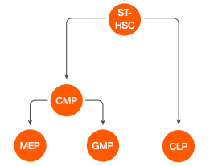

Therefore we will create four volcanoplots that compare the different cell-type (stages). CLP will be compared to HSC. CMP will be comared to HSC. And then MEP and GMP will be compared to CMP. In order to prepare the data for these volcanoplots there must be for each pair of compared cell-types be created a variable of log2-fold-change and of q-value. To figure out this data wrangling took quite a bit of effort. In the end what was done is to subset the full dataframe to the two cell types in question, then summarize to mean and standard deviation values, then transfer to wide format,

#### Getting mean values and standard deviation for volcano plot

The mean value between each replicate of the cell samples are estimated along with the standard deviation, to create a new tibble which is used to create a volcano plot for the fold change.

```r
# create a tibble with mean values and standard deviation
df_sample_mean <- df_sample_wise|>
  group_by(protein_groups,
           cell_type) |> # take the mean/sd of of the replicates for the protein groups and cell types
  summarise(
    mean = mean(intensity),
    sd = sd(intensity)
    ) |>
  pivot_wider(names_from = cell_type,
              values_from = c(mean,sd))
# Showing 10 rows of the df_sample mean table
sample_n(df_sample_mean, 1)
```

```
# A tibble: 3,763 × 11
# Groups:   protein_groups [3,763]
   protein_groups     mean_clp mean_cmp mean_gmp mean_hsc mean_mep sd_clp sd_cmp
   <chr>                 <dbl>    <dbl>    <dbl>    <dbl>    <dbl>  <dbl>  <dbl>
 1 A1L314                0.609    0.334    0.350    0.325    0.394 0.268  0.0190
 2 A1L317                0.320    0.334    0.350    0.325    0.593 0.0656 0.0190
 3 A2A432;A2A432-2       0.319    0.334    0.350    0.325    0.805 0.0284 0.0190
 4 A2A8Z1;A2A8Z1-2       0.319    0.529    0.350    0.325    0.394 0.0284 0.237
 5 A2AAJ9;A2AAJ9-2       0.319    0.625    0.350    0.325    0.394 0.0284 0.346
 6 A2AB59;A2AB59-2       0.319    0.334    0.350    0.325    0.539 0.0284 0.0190
 7 A2ABU4                0.319    0.729    0.350    0.325    0.394 0.0284 0.266
 8 A2ADY9                0.817    0.736    0.880    0.939    0.746 0.261  0.286
 9 A2AGT5;A2AGT5-2;A…    0.935    0.334    1.05     1.06     0.868 0.330  0.0190
10 A2AIV8                0.319    0.334    0.959    0.325    0.394 0.0284 0.0190
# ℹ 3,753 more rows
# ℹ 3 more variables: sd_gmp <dbl>, sd_hsc <dbl>, sd_mep <dbl>
```

```r
# Saving the dataframe for presentation purposes
write_tsv(df_sample_mean, file = here("data/03_df_sample_mean.tsv.gz"))
```

### Estamating p.value, log2fold change and q.value

Computing the ratio of means for each protein group as well as compute the p-value which is then p.adjusted to the q-value. In order to compute p-value based on means and standard deviations a function was created that computes p-value for a two-sided student t-test of two populations based on means, standard deviations and number of replicates as input - The function can be found in 99_functions.R.

```r
#Computing new variables that calculate fold, p_val and q_val
df_volcano_clp_hsc <- df_sample_mean |>
  ungroup() |>
  select(c(protein_groups,mean_hsc,sd_hsc,mean_clp,sd_clp)) |>
  mutate(fold_log2 = log2(mean_clp/mean_hsc),
         #See the p-value function in 99_functions.R
       p_val = pval(mu1 = mean_clp, mu2 = mean_hsc, n1 = 5, n2 = 4, s1 = sd_clp, s2 = sd_hsc),
       q_val = (p.adjust(p_val))) |> #including variable overexpressed stating if proteins are over- or underexpressed or not significant
  mutate(expression = case_when(fold_log2 > 0 & q_val <= 0.05~ "overexpressed",
                                fold_log2 < 0 & q_val <= 0.05 ~ "underexpressed",
                                q_val >0.05  ~ "not significant")) |> #removing colomns unnecesary for volcanoplot
  select(protein_groups, fold_log2, q_val, expression)


sample_n(df_volcano_clp_hsc,10)
```

```
# A tibble: 10 × 4
   protein_groups  fold_log2 q_val expression
   <chr>               <dbl> <dbl> <chr>
 1 P13542             1.70       1 not significant
 2 Q8CI59            -0.0238     1 not significant
 3 P24547            -0.0882     1 not significant
 4 Q9CQF3            -0.0660     1 not significant
 5 Q9CYH2             0.882      1 not significant
 6 Q9CX00             0.997      1 not significant
 7 O08795;O08795-2    0.0401     1 not significant
 8 P42567             1.31       1 not significant
 9 Q9D0J8             0.276      1 not significant
10 Q6ZPE2;Q6ZPE2-2   -0.0238     1 not significant
```

### Check our function

The previous code returns a tibble with log2(fold change), log10(pvalues) and q. values to define if a protein is over or underexpressed. The code is however long and tedious, considering that it must be replicated 3 other times. Hence a home brewed function `volcano_augment` was made, which takes the table with mean values for each protein group, subsets the cell types, takes the log2(fold change) and estimates the q.value - which is used to define expression state.

```r
# Checking if our home_brew p.value and q.value function... functions.
new_volcano_clp_hsc <- volcano_augment(df = df_sample_mean,
                                       later_cell = "clp",
                                       earlier_cell = "hsc",
                                       n_later = 5,
                                       n_earlier = 4)
write_tsv(df_volcano_clp_hsc,
          file = str_c(here("data"), "df_volcano_clp_hsc.tsv.gz", sep = "/")) # Writing to tsv


# Testing if the function for creating volcano-plot values work, by comparing to the manually created tibble.
as_tibble(new_volcano_clp_hsc == df_volcano_clp_hsc) |>
  sample_n(size = 10)
```

```
# A tibble: 10 × 4
   protein_groups fold_log2 q_val expression
   <lgl>          <lgl>     <lgl> <lgl>
 1 TRUE           TRUE      TRUE  TRUE
 2 TRUE           TRUE      TRUE  TRUE
 3 TRUE           TRUE      TRUE  TRUE
 4 TRUE           TRUE      TRUE  TRUE
 5 TRUE           TRUE      TRUE  TRUE
 6 TRUE           TRUE      TRUE  TRUE
 7 TRUE           TRUE      TRUE  TRUE
 8 TRUE           TRUE      TRUE  TRUE
 9 TRUE           TRUE      TRUE  TRUE
10 TRUE           TRUE      TRUE  TRUE
```

Repeating the same data wrangling for the remaining three volcano plots is automatized using the function `volcano_augment`

```r
# Input to the function is dataframe, cell types to compare and no of replicates in cell types.
# All files are saved as tsv.gz.

# creating tibble for comparing cmp to hsc
df_volcano_cmp_hsc <- volcano_augment(df = df_sample_mean,
                                      later_cell = "cmp",
                                      earlier_cell = "hsc",
                                      n_later = 4,
                                      n_earlier = 4)
write_tsv(df_volcano_cmp_hsc,
          file = str_c(here("data"), "df_volcano_cmp_hsc.tsv.gz", sep = "/")) # Writing to tsv

# creating tibble for comparing mep to cmp
df_volcano_mep_cmp <- volcano_augment(df = df_sample_mean,
                                      later_cell = "mep",
                                      earlier_cell = "cmp",
                                      n_later = 4,
                                      n_earlier = 4)
write_tsv(df_volcano_mep_cmp,
          file = str_c(here("data"), "df_volcano_mep_cmp.tsv.gz", sep = "/")) # wrting to tsv

# creating tibble for comparing gmp to cmp
df_volcano_gmp_cmp <- volcano_augment(df = df_sample_mean,
                                      later_cell = "gmp",
                                      earlier_cell = "cmp",
                                      n_later = 4,
                                      n_earlier = 4)
write_tsv(df_volcano_gmp_cmp,
          file = str_c(here("data"), "df_volcano_gmp_cmp.tsv.gz", sep = "/")) # Writing to tsv
```

## Saving data files

Files used in downstream 04_describe and 05/06_analysis are saved.

```r
# Directing pathway to store the .tsv  file

file_name <- "03_df_log_intensities.tsv.gz"

write_tsv(df_log_intensities, str_c(data_path, file_name,sep = "/"))

#Writing and saving the clean dataframe to 02_df_clean.tsv.
```

#### Saving the data frame with imputed missing values in long format

```r
# Directing pathway to store the .tsv  file

file_name <- "03_df_norm_intensities.tsv.gz"

write_tsv(df_norm_intensities, str_c(data_path, file_name,sep = "/"))

#Writing and saving the clean dataframe to 02_df_clean.tsv.
```

```r
write_tsv(df_feature_wise, file = here("data/03_df_feature_wise.tsv.gz"))
```

```r
write_tsv(df_sample_wise, file = here("data/03_df_sample_wise.tsv.gz"))
```

```r
write_tsv(df_feature_wide, file = here("data/03_df_feature_wide.tsv.gz"))
```

## 03_augment conclusion:

The cleaned data: df_intensities_long has been log-transformed for compression of intensities, normalized for comparability across cell-types and missing values have been imputed depending on the downstream analysis. Furthermore the dataframes were turned to wide-format with names originating from either cell_types or protein_groups, once again used depending on the downstream analysis.

## Library

```r
library(tidyverse)
library(ggplot2)
library(here)
source(here("R/99_functions.R"))
```

## Load data

```r
df_intensities <- read_tsv(file = here("data/02_df_intensities.tsv.gz"))

df_log_intensities <- read_tsv(file = here("data/03_df_log_intensities.tsv.gz"))

df_norm_intensities <- read_tsv(file = here("data/03_df_norm_intensities.tsv.gz"))

df_feature_wise <- read_tsv(file = here("data/03_df_feature_wise.tsv.gz"))

df_sample_wise <- read_tsv(file = here("data/03_df_sample_wise.tsv.gz"))
```

## The Data Set

We are working with an unpublished proteomics dataset from a research group on DTU. We have recieved permission to work with the data for the R for Bio Data Science Project. The dataset relates to a study that can be read about in this preprint. (insert link here).

In the study, proteomics by mass spectrometry was applied to FACS-sorted populations of hematopoietic stem- and progenitor cells from the mouse bone marrow. Five populations were isolated based on known surface marker expression: Hematopoietic stem cells (HSC), common lymphoid progenitors (CLP), common myeloid progenitors (CMP), megakaryocyte-erythrocyte progenitors (MEP) and granulocyte-monocyte progenitors (GMP). According to literature, these cell populations represent different stages of hematopoiesis, meaning the differentiation of HSC into the different blood cell lineages. For each cell type, 500 cells were isolated in 4 replicates, except for CLP having 5 replicates. The sorted cells were lysed, digested with trypsin, and subjected to proteomics by mass spectrometry in data-independent acquisition (DIA) mode. Therefore our raw data consists of LS/MS DIA intensity values of identified protein groups (PG).

Table 1: Number of replicates and observations across replicates for the analysed FACS-populations

[output not shown]

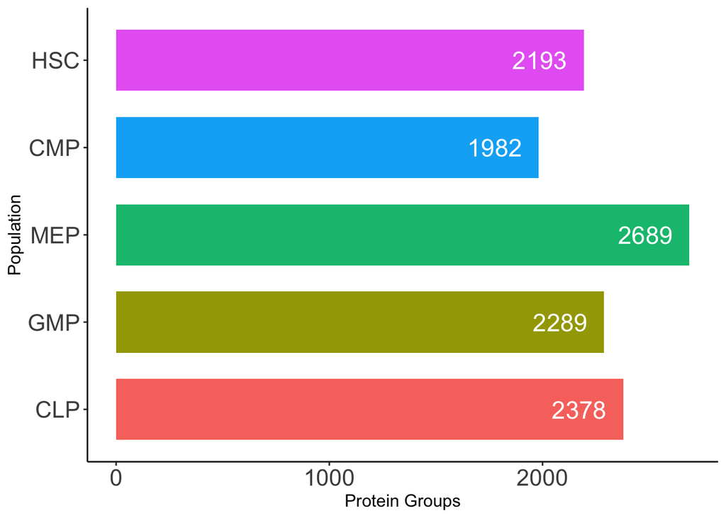

```r
# simple bar chart with total number protein groups per cell type
df_norm_intensities |>
  mutate(
    cell_type = factor(cell_type, levels=(c("clp", "gmp", "mep", "cmp", "hsc"))),
    cell_type = fct_recode(cell_type,
                         "HSC" = "hsc",
                         "CMP" = "cmp",
                         "MEP" = "mep",
                         "GMP" = "gmp",
                         "CLP" = "clp")) |>
  filter(!is.na(intensity)) |>
  group_by(protein_groups) |>
  distinct(cell_type, .keep_all=TRUE) |>
  ggplot(mapping = aes(y=cell_type)) +
  geom_bar(aes(fill = cell_type), width = 0.7) +
  geom_text(stat = "count", aes(label = ..count..), hjust = 1.3, size = 6, color = "white") +
  theme_classic() +
  theme(
    axis.text.x = element_text(size = 16),
    axis.text.y = element_text(size = 16),
    axis.title.x = element_text(size = 12),
    axis.title.y = element_text(size = 12)
  ) +
  guides(fill = "none") +
  xlab("Protein Groups") +
  ylab("Population")
```

### Data completeness: Percentage of missing values

For many downstream analyses, it is important to know the data completeness, meaning the percentage of non-NA values in the data.

```r
# print percentage of missing values for each cell type
df_norm_intensities |>
  group_by(cell_type) |>
  summarise(total_NA = sum(is.na(intensity)),
            total_non_NA = sum(!is.na(intensity))) |>
  mutate(data_completeness = total_non_NA/(total_NA + total_non_NA))
```

```
# A tibble: 5 × 4
  cell_type total_NA total_non_NA data_completeness
  <chr>        <int>        <int>             <dbl>
1 clp           8871         9944             0.529
2 cmp           7784         7268             0.483
3 gmp           6457         8595             0.571
4 hsc           6711         8341             0.554
5 mep           6835         8217             0.546
```

We can see that we have only about 50 percent data completeness for each cell type. This makes sense, because the proteome changes with differentiation.

### Investigate shared observations between cell types

To understand the proteomic changes over the course of stem cell differentiation, it is helpful to calculate the overlap of the PG’s identified in each cell type. This has implications for further data processing, guiding decisions like handling of NA’s.

```r
# make vectors of ID's in every cell type

list_hsc <- df_intensities |>
  filter(cell_type=="hsc") |>
  filter(!is.na(intensity)) |>
  pull(protein_groups) |>
  unique()

list_cmp <- df_intensities |>
  filter(cell_type=="cmp") |>
  filter(!is.na(intensity)) |>
  pull(protein_groups) |>
  unique()

list_gmp <- df_intensities |>
  filter(cell_type=="gmp") |>
  filter(!is.na(intensity)) |>
  pull(protein_groups) |>
  unique()

list_clp <- df_intensities |>
  filter(cell_type=="clp") |>
  filter(!is.na(intensity)) |>
  pull(protein_groups) |>
  unique()

list_mep <- df_intensities |>
  filter(cell_type=="mep") |>
  filter(!is.na(intensity)) |>
  pull(protein_groups) |>
  unique()

# Make list intersection to see number of protein groups in samples of all cell types
combined_lists <- list(list_hsc, list_clp, list_cmp, list_gmp, list_cmp)

# Find the intersection of all lists
intersection <- reduce(combined_lists, intersect)
print(str_c(" There are ", length(intersection), " protein groups detected across all cell types"))
```

```
[1] " There are 1437 protein groups detected across all cell types"
```

## Log2 Transformation

Plot of the PG intensity density prior to Log2 transformation

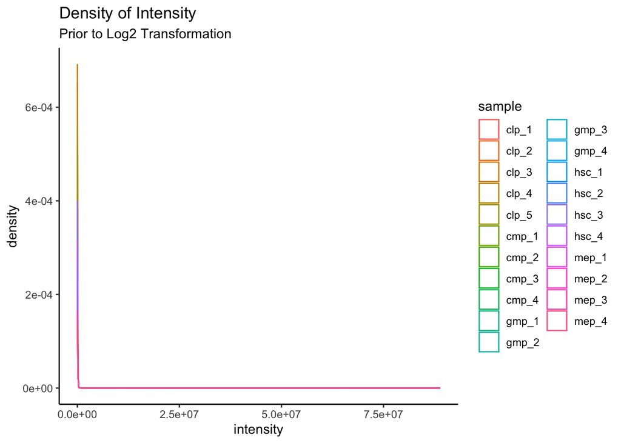

```r
df_intensities |>
  mutate(sample = str_c(cell_type,
                        replicate_n,
                        sep ="_"),.before = cell_type) |>
  ggplot(aes(x=intensity, colour = sample)) +
  geom_density() +
  theme_classic()+
  labs(title = "Density of Intensity", subtitle = "Prior to Log2 Transformation")
```

As seen in the plot, the PG intensities span a large dynamic range. For the reasons explained before, we log2-transformed the data.

Plot of the PG intensity density after Log2 transformation

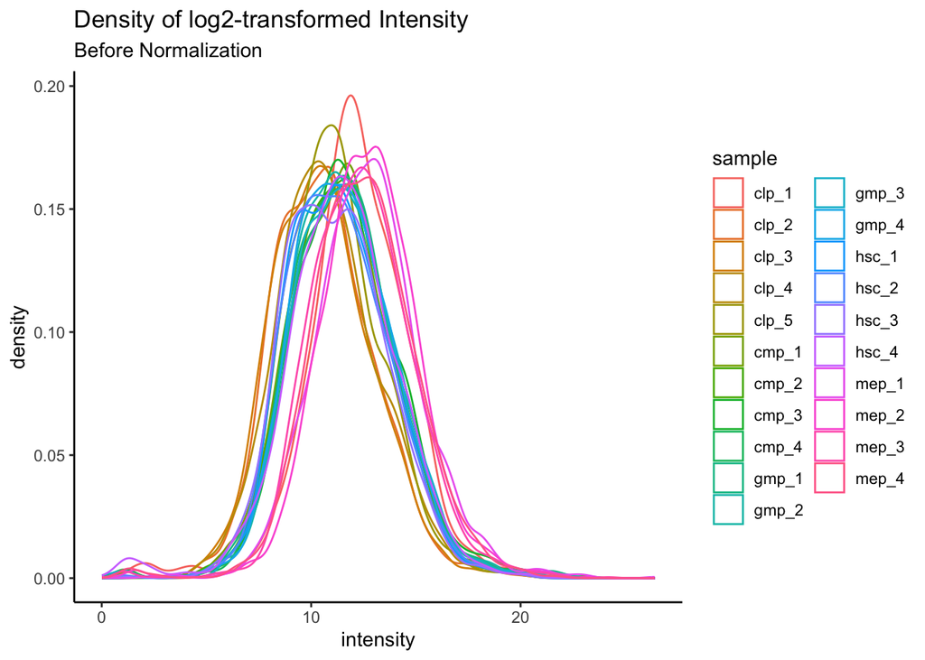

```r
df_log_intensities |>
    mutate(sample = str_c(cell_type,
                        replicate_n,
                        sep ="_"),.before = cell_type) |>
  ggplot(aes(x=intensity, colour = sample)) +
  geom_density() +
  theme_classic()+
  labs(title = "Density of log2-transformed Intensity", subtitle = "Before Normalization")
```

```r
  ggsave(filename = "plot_before_normalization,.png",
       width = 20, height = 10, units = "cm",
       path = here("results"))
```

```r
df_log_intensities |>
    mutate(sample = str_c(cell_type,
                        replicate_n,
                        sep ="_"),.before = cell_type) |>
  group_by(sample) |>
  summarize(median(intensity, na.rm = TRUE))
```

```
# A tibble: 21 × 2
   sample `median(intensity, na.rm = TRUE)`
   <chr>                              <dbl>
 1 clp_1                               12.2
 2 clp_2                               10.5
 3 clp_3                               10.4
 4 clp_4                               10.6
 5 clp_5                               11.0
 6 cmp_1                               11.4
 7 cmp_2                               11.4
 8 cmp_3                               11.5
 9 cmp_4                               11.4
10 gmp_1                               11.5
# ℹ 11 more rows
```

The intensities now follow a log-normal distribution. However, we can see that the medians of the sample densities differ. For the reasons explained before, we normalized the PG intensities on the sample median.

## Normalization

Plot of the PG intensity density after Log2 transformation and normalization

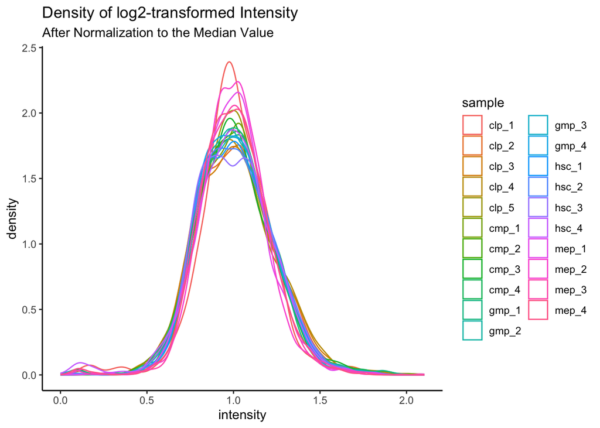

```r
df_norm_intensities |>
    mutate(sample = str_c(cell_type,
                        replicate_n,
                        sep ="_"),.before = cell_type) |>
  ggplot(aes(x=intensity,
  colour = sample)) +
  geom_density() +
  theme_classic()+
  labs(title = "Density of log2-transformed Intensity", subtitle = "After Normalization to the Median Value")
```

```r
  ggsave(filename = "plot_after_normalization,.png",
       width = 20, height = 10, units = "cm",
       path = here("results"))
```

```r
df_norm_intensities |>
  mutate(sample = str_c(cell_type,
                      replicate_n,
                      sep ="_"),.before = cell_type) |>
  group_by(sample) |>
  summarize(median(intensity, na.rm = TRUE))
```

```
# A tibble: 21 × 2
   sample `median(intensity, na.rm = TRUE)`
   <chr>                              <dbl>
 1 clp_1                                  1
 2 clp_2                                  1
 3 clp_3                                  1
 4 clp_4                                  1
 5 clp_5                                  1
 6 cmp_1                                  1
 7 cmp_2                                  1
 8 cmp_3                                  1
 9 cmp_4                                  1
10 gmp_1                                  1
# ℹ 11 more rows
```

We can now observe identical medians of 1 for all samples.

## Missing Value Imputation

As explained before, NA’s need to be replaced by meaningful values. We explored two options:  
sample-wise and feature-wise imputation.

### Sample-wise imputation

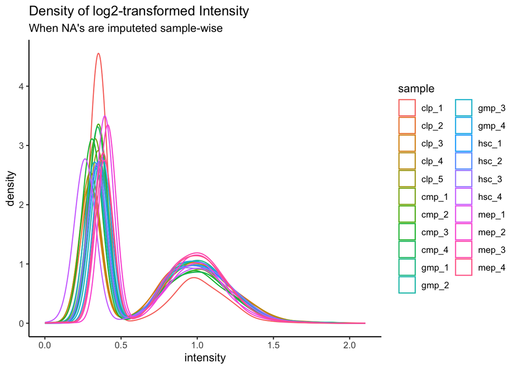

```r
df_sample_wise |>
  mutate(sample = str_c(cell_type,
                        replicate_n,
                        sep ="_"),.before = cell_type) |>
  ggplot(aes(x=intensity, colour = sample)) +
  geom_density() +
  theme_classic()+
  labs(title = "Density of log2-transformed Intensity", subtitle = "When NA's are imputeted sample-wise")
```

We can observe a heavy distortion of the density plots in all samples, provoked by replacing NA’s sample-wise. This is not necessarily bad, as we needed the log-normal distribution to calculate the z-scores for replacement.

### Feature-wise imputation

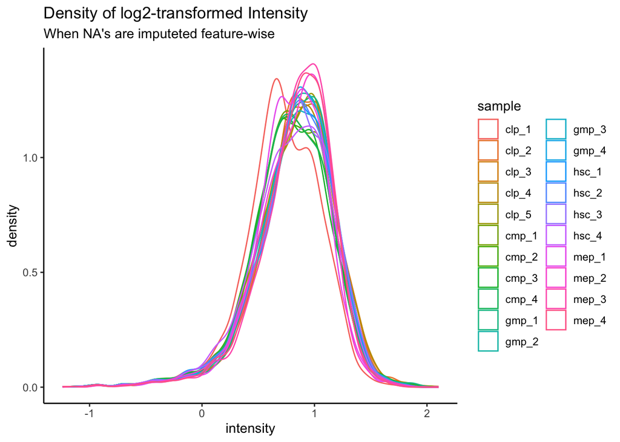

```r
df_feature_wise |>
  mutate(sample = str_c(cell_type,
                        replicate_n,
                        sep ="_"),.before = cell_type) |>
  ggplot(aes(x=intensity, colour = sample,
             color = replicate_n)) +
  geom_density() +
  theme_classic()+
  labs(title = "Density of log2-transformed Intensity", subtitle = "When NA's are imputeted feature-wise")
```

We observe a less apparent distortion of the density plots, instead of a new global maximum at the 0.1 percentile mark, we have left-skewed densities.  
Choice of NA imputation: We need to base our decision on the nature of the data we are working with. Both strategies would produce meaningful replacement values for NA’s. Because the missingness in our data is MNAR, we chose sample-wise imputation, as it accounts better for biological missingness in DIA data.

## Protein type lookup

To get deeper insight in our data, we wanted to explore how many proteins in each sample are involved in regulation of gene expression. We follow the central dogma of biology, consisting of transcription, mRNA processing, translation and protein degradation. One way to do that is by systematic lookup of gene ontology (GO) terms or pathways in data bases like uniprot. Because we’re limited to few packages, we did not make use of the uniprot API, to access the data base directly. Instead, we downloaded a tsv file with all reviewed mouse proteins, to do a manual lookup. For simplicity, we used uniprot keywords instead of GO terms or pathways. This is mainly a showcase of a manual lookup, instead of a solid biological interrogation.

```r
# load mouse uniprot db file for lookup

df_uniprot_mouse <- read_tsv(file = here("data/01_dat_load_uniprot_mouse.tsv"))
```

```r
# make new data frame with keyword column, using unipro_lookup to lookup keywords for all found proteins in the uniprot file. This will take a reasonable amount of time (about 3 minutes).

df_type <- df_norm_intensities |>
  filter(!is.na(genes) & genes != "") |>
  mutate(description_column = map_chr(
     .x = genes,
     .f = ~uniprot_lookup(gene_id=.x, dataframe=df_uniprot_mouse, id_column=`Gene Names`, keyword_column=Keywords)
   ))
```

```r
# Make rule for presence in a sample: needs to be present in at least 2 replicates

df_type <- df_type |>
  group_by(protein_groups, cell_type) |>
  filter(sum(!is.na(intensity)) >= 2) |>
  ungroup()
```

```r
# make column with extracted keywords (selected by us)

df_type <- df_type |>
  mutate(
    keyword_function = case_when(
      str_detect(description_column, "Transcription regulation") ~ "Transcription regulation",
      str_detect(description_column, "mRNA splicing") ~ "mRNA splicing",
      str_detect(description_column, "Translation regulation") ~ "Translation regulation",
      str_detect(description_column, "Proteasome") ~ "Proteasome",
      TRUE ~ NA
    )
  )
```

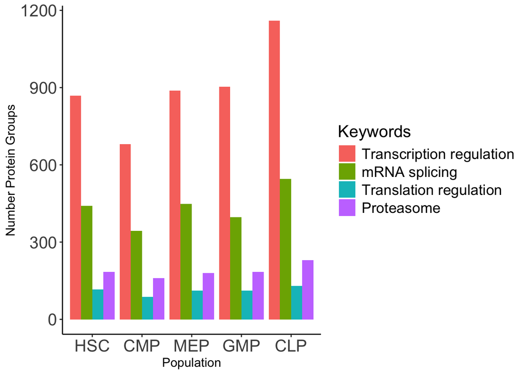

```r
# make simple grouped bar plot to show absolute numbers of protein groups for each keyword category across cell types

plot_uniprot <- df_type |>
  mutate(
    keyword_function = factor(keyword_function, levels=(c("Transcription regulation",
                                                          "mRNA splicing",
                                                          "Translation regulation",
                                                          "Proteasome"))),
    cell_type = factor(cell_type, levels=(c("hsc", "cmp", "mep", "gmp", "clp"))),
    cell_type = fct_recode(cell_type,
                         "HSC" = "hsc",
                         "CMP" = "cmp",
                         "MEP" = "mep",
                         "GMP" = "gmp",
                         "CLP" = "clp")) |>
  filter(!is.na(keyword_function)) |>
  ggplot(mapping = aes(x=cell_type, fill=keyword_function)) +
  geom_bar(position = position_dodge()) +
  theme_classic() +
  theme(
  axis.text.x = element_text(size = 16),
  axis.text.y = element_text(size = 16),
  axis.title.x = element_text(size = 12),
  axis.title.y = element_text(size = 12)) +
  xlab("Population") +
  ylab("Number Protein Groups") +
  guides(fill = guide_legend(title = "Keywords")) +
  theme(
    legend.text = element_text(size = 14),
    legend.title = element_text(size = 16)
  )


print(plot_uniprot)
```

```r
# save plot

plot_uniprot <- ggsave(filename = "plot_uniprot.png",
       width = 30, height = 10, units = "cm",
       path = here("results"))
```

Those results do not reflect common knowledge about proteomics data of gene regulation. Although transcription factors make up 10% of protein-coding genes and are therefore one of the biggest known functional groups of proteins, they are usually low expressed and not easily picked up by low-input proteomics. Especially since only about 3700 protein groups were detected in this data set. It seems that uniprot keywords are very broad descriptions of protein function, e.g. include proteins in “Transcription regulation” that are active in pathways remotely connected to this term.

It should be noted that the performance of the lookup is bad, as it takes considerable time to complete it. Reason is that for every protein group in our data, the whole uniprot data frame is parsed. This is suboptimal, however the only solution we could come up with to do the pattern matching of proteins in the protein groups. If this wasn’t necessary, a simple join could be made which would increase performance considerably.

## Libraries

```r
library(tidyr)
library(graphics)
library(broom)
source(here("R/99_functions.R"))
#options(bitmapType = 'cairo')
```

## PCA plots and variance analysis

```r
df_input <- df_feature_wide |> select(-c('replicate_n','cell_type'))

colourby <- pull(df_feature_wide, 'cell_type')

#Projecting data unto principal components (pc)
pc <- prcomp(df_input, center = FALSE, scale = FALSE)

#Gives an overview, you should be able to tell the variance already here even without the plot
summary(pc)
```

```
Importance of components:
                           PC1     PC2     PC3     PC4     PC5     PC6     PC7
Standard deviation     51.8863 4.22175 3.42604 3.31876 3.00879 2.46014 1.72479
Proportion of Variance  0.9718 0.00643 0.00424 0.00398 0.00327 0.00218 0.00107
Cumulative Proportion   0.9718 0.97822 0.98246 0.98643 0.98970 0.99188 0.99296
                           PC8     PC9    PC10    PC11   PC12    PC13    PC14
Standard deviation     1.68779 1.50708 1.47935 1.38020 1.2879 1.23725 1.11836
Proportion of Variance 0.00103 0.00082 0.00079 0.00069 0.0006 0.00055 0.00045
Cumulative Proportion  0.99399 0.99481 0.99560 0.99628 0.9969 0.99744 0.99789
                          PC15    PC16    PC17    PC18    PC19    PC20    PC21
Standard deviation     1.11331 1.03241 0.95393 0.87634 0.84342 0.79223 0.72908
Proportion of Variance 0.00045 0.00038 0.00033 0.00028 0.00026 0.00023 0.00019
Cumulative Proportion  0.99833 0.99872 0.99905 0.99932 0.99958 0.99981 1.00000
```

```r
#Plots the principal component values (pc$x)

pca_plot <- pc$x |> as.data.frame() |>
  ggplot(aes(x = PC1, y = PC2, color = colourby)) +
  geom_point(size = 2.5) +
  labs(title = 'Principal component analysis',
       subtitle = 'Clustering of cell types on protein expression',
       color = 'Cell Type') +
  theme_classic() +
  theme(legend.position = 'right')
```

```r
pc_varianceplot <- pc |>
  tidy(matrix = "eigenvalues") |>
  filter(PC <= 5) |>
  ggplot(aes(PC, percent)) +
  geom_col(fill = "#56B4E9", alpha = 0.8) +
  scale_x_continuous(breaks = 1:9) +
  scale_y_continuous(
    labels = scales::percent_format(),
    expand = expansion(mult = c(0, 0.01))
  ) +
  theme_classic() +
  ylab('Porportion of Variance (%)')
```

## Save plot

```r
ggsave(plot = pca_plot, filename = "PCA_on_proteingroups_original.png", width = 15, height = 10, units = "cm", path = here("results"))

ggsave(plot = pc_varianceplot, filename = "pca_variance_barplot.png", width = 15, height = 10, units = "cm", path = here("results"))
```

## Plot PCA

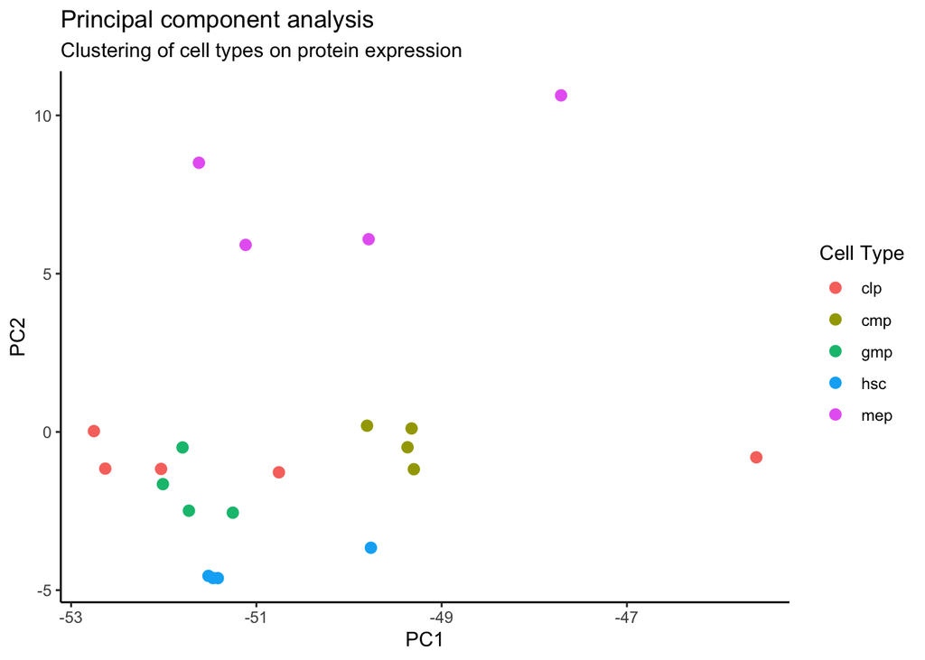

```r
pca_plot
```

## Plot Variance explained

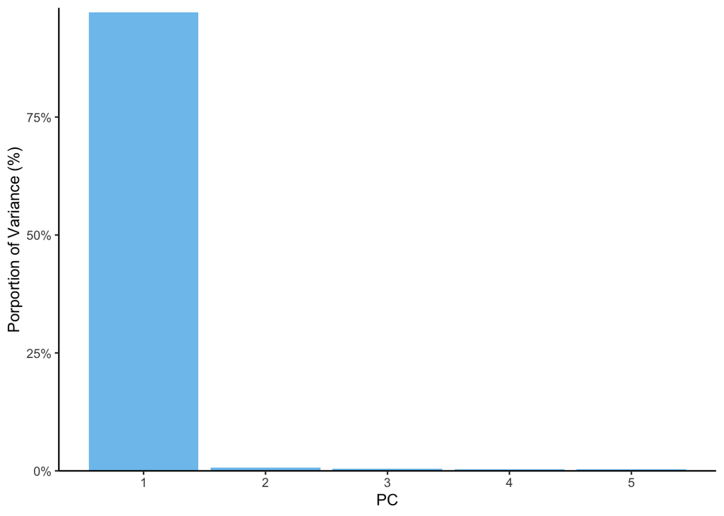

```r
pc_varianceplot
```

## Library

```r
library("tidyverse")
library("broom")
library("ggthemes")
library("ggrepel")
library("ggplot2")
library("patchwork")
library(graphics)
source(here("R/99_functions.R"))
```

## Load data

Loading in the data from 03_augment for the volcano plots.

```r
df_volcano_clp_hsc <- read_tsv(file = str_c(here("data"), "df_volcano_clp_hsc.tsv.gz", sep = "/"))

df_volcano_cmp_hsc <- read_tsv(file = str_c(here("data"), "df_volcano_cmp_hsc.tsv.gz", sep = "/"))

df_volcano_gmp_cmp <- read_tsv(file = str_c(here("data"), "df_volcano_gmp_cmp.tsv.gz", sep = "/"))

df_volcano_mep_cmp <- read_tsv(file = str_c(here("data"), "df_volcano_mep_cmp.tsv.gz", sep = "/"))
```

## Volcano plots

P05213 is tubulin, tubulin is the major constituent of microtubules, a cylinder consisting of laterally associated linear protofilaments composed of alpha- and beta-tubulin heterodimers.

Q9WUA1 is an inhibitory factor that binds to WNT proteins and inhibits their activities. May be involved in mesoderm segmentation.

We will look at the development from HSC to CLP and from HSC to CMP.

And then from CMP to MEP and from CMP to GMP. Because that is the order in which the cells develop.

## Creating and saving volcano plots

The volcano plot tibbles created in 03_augment are used to create volcano plots with ggplot. The plots are saved to variables which are used to render image.png files used in the presentation

### Comparing clp to hsc

```r
plot_clp_hsc <- df_volcano_clp_hsc |>
  mutate(label = case_when(expression == "overexpressed" & fold_log2 > 2 ~ protein_groups,.default = "")) |>
  ggplot(aes(x = fold_log2, y = desc(log10(q_val)), color = expression))+
  geom_point(size=0.5, alpha = 0.5)+
  theme_classic()+
  geom_text_repel(aes(label = label), size = 3)+
  labs(title = "Expression of CLP relative to HSC",
       x = "Log2fold-change",
       y = "-log10(q)",
       caption = "proteomics data")+
  theme(legend.position = "bottom",
        legend.title = element_blank(),
        legend.text = element_text(size = 12))+
  guides(color = guide_legend(override.aes = list(shape = 19, size = 5, alpha = 1)))+
  #The horizontal line that indicates significance
#  geom_hline(yintercept = 2)+
  scale_color_manual(values = c("overexpressed" = "#D55E00", "underexpressed" = "#0072B2", "not_significant" = "gray"))
```

### Comparing cmp to hsc

```r
plot_cmp_hsc <- df_volcano_cmp_hsc|>
  mutate(label = case_when(expression == "overexpressed" & fold_log2 > 2 ~ protein_groups,.default = "")) |>
  ggplot(aes(x = fold_log2, y = desc(log10(q_val)), color = expression))+
  geom_point(size=0.5, alpha = 0.5)+
  theme_classic()+
  geom_text_repel(aes(label = label), size = 3)+
  labs(title = "Expression of CMP relative to HSC",
       x = "Log2fold-change",
       y = "-log10(q)",
       caption = "proteomics data")+
  theme(legend.position = "bottom",
        legend.title = element_blank(),
        legend.text = element_text(size = 12))+
  guides(color = guide_legend(override.aes = list(shape = 19, size = 5, alpha = 1)))+
  #The horizontal line that indicates significance
#  geom_hline(yintercept = 2)+
  scale_color_manual(values = c("overexpressed" = "#D55E00", "underexpressed" = "#0072B2", "not_significant" = "gray"))
```

### Comparing mep to cmp

```r
plot_mep_cmp <- df_volcano_mep_cmp |>
  mutate(label = case_when(expression == "overexpressed" & fold_log2 > 2 ~ protein_groups,.default = "")) |> # creates a label if it is overexpressed
  ggplot(aes(x = fold_log2, y = desc(log10(q_val)), color = expression))+
  geom_point(size=0.5, alpha = 0.5)+
  theme_classic()+
  geom_text_repel(aes(label = label), size = 3)+
  labs(title = "Expression of MEP relative to CMP",
       x = "Log2fold-change",
       y = "-log10(q)",
       caption = "proteomics data")+
  theme(legend.position = "bottom",
        legend.title = element_blank(),
        legend.text = element_text(size = 12))+
  guides(color = guide_legend(override.aes = list(shape = 19, size = 5, alpha = 1)))+
  #The horizontal line that indicates significance
#  geom_hline(yintercept = 2)+
scale_color_manual(values = c("overexpressed" = "#D55E00", "underexpressed" = "#0072B2", "not_significant" = "gray"))
```

### Comparing cmp to gmp

```r
plot_gmp_cmp <- df_volcano_gmp_cmp |>
  mutate(label = case_when(expression == "overexpressed" & fold_log2 > 2 ~ protein_groups,.default = "")) |>
  ggplot(aes(x = fold_log2, y = desc(log10(q_val)), color = expression))+
  geom_point(size=0.5, alpha = 0.5)+
  theme_classic()+
  geom_text_repel(aes(label = label), size = 3)+
  labs(title = "Expression of GMP relative to CMP",
       x = "Log2fold-change",
       y = "-log10(q)",
       caption = "proteomics data")+
  theme(legend.position = "bottom",
        legend.title = element_blank(),
        legend.text = element_text(size = 12))+
  guides(color = guide_legend(override.aes = list(shape = 19, size = 5, alpha = 1)))+
  #The horizontal line that indicates significance
#  geom_hline(yintercept = 2)+
  scale_color_manual(values = c("overexpressed" = "#D55E00",
                                "underexpressed" = "#0072B2",
                                "not_significant" = "gray"))
```

### Rendering the plots as image.png for the quarto_presentation

```r
#Due to an error occuring when saving ggplot directly in the pipeline of the latest plot which apparently is caused by a recent edit in ggplot2-3.3.4 the saving of plots is done separately.

# save hsc_clp
ggsave(plot = plot_clp_hsc,
       filename = "hsc_clp_volcano_plot.png",
       width = 20, height = 10, units = "cm",
       path = here("results"))

# save hsc_cmp
ggsave(plot = plot_cmp_hsc,
       filename = "hsc_cmp_volcano_plot.png",
       width = 20, height = 10, units = "cm",
       path = here("results"))

# save cmp_mep
ggsave(plot = plot_mep_cmp,
       filename = "cmp_mep_volcano_plot.png",
       width = 20, height = 10, units = "cm",
       path = here("results"))

# save gmp_cmp
ggsave(plot = plot_gmp_cmp,
       filename = "cmp_gmp_volcano_plot.png",
       width = 20, height = 10, units = "cm",
       path = here("results"))
```

A future direction for the project would be to assign all the protein groups categories based on their functionality. It would for instance be interesting to see which are the proteins that are overexpressed in the different cell types, but since there are so many of them it does not make sense to label all of them. We might for instance label the proteins that have a 2logfold change above 2, which means they are overexpressed by 400%.

## Showing the volcano plots

### CLP compared to HSC

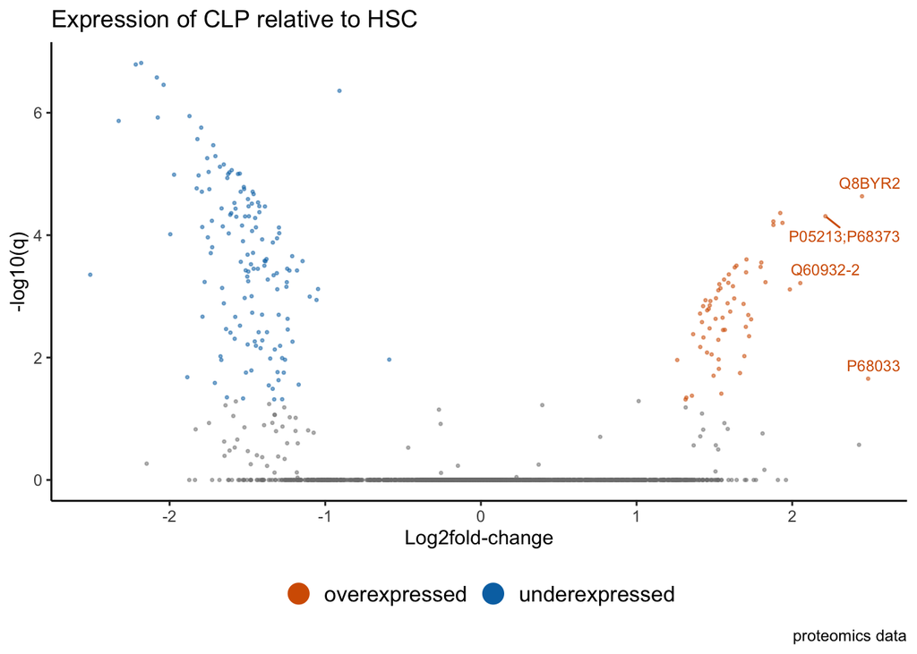

```r
plot_clp_hsc
```

### CMP compared to HSC

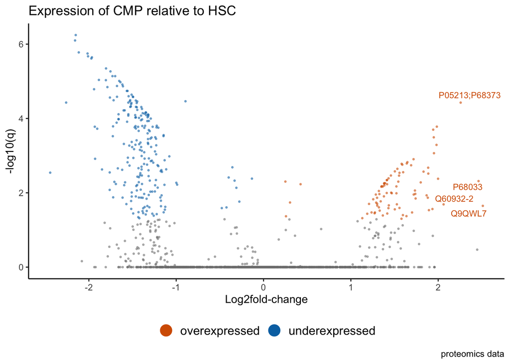

```r
plot_cmp_hsc
```

### GMP compared to CMP

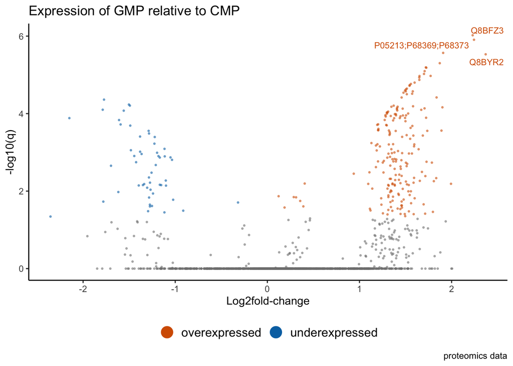

```r
plot_gmp_cmp
```

### MEP compared to CMP

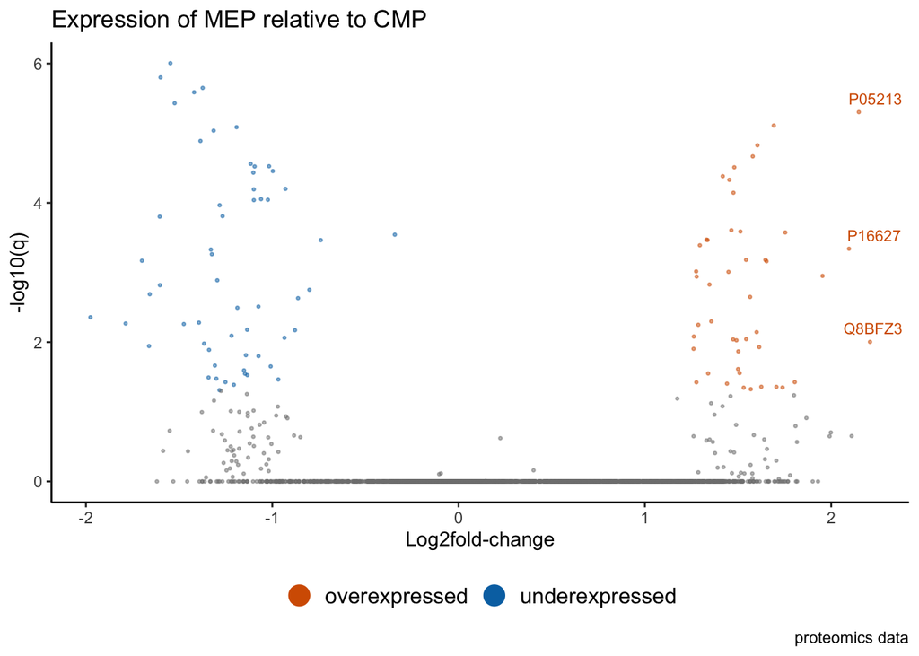

```r
plot_mep_cmp
```

Lets have a look at hsc to cmp.

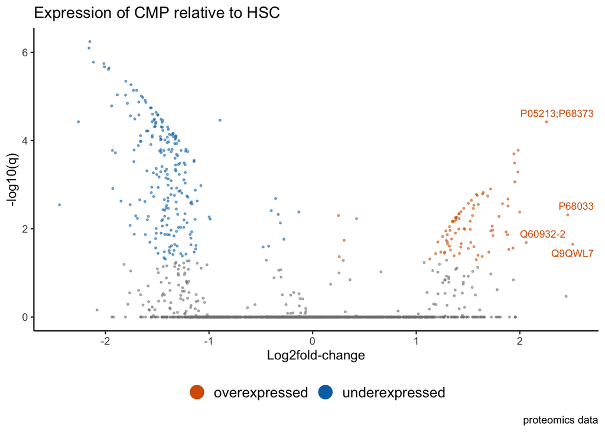

```r
# loading the plot from variable
plot_cmp_hsc
```

P68033 is an actin, actins are highly conserved proteins that are involved in various types of cell motility and are ubiquitously expressed in all eukaryotic cells.

P05213 is tubulin, tubulin is the major constituent of microtubules, a cylinder consisting of laterally associated linear protofilaments composed of alpha- and beta-tubulin heterodimers.

Q9WUA1 is an inhibitory factor that binds to WNT proteins and inhibits their activities. May be involved in mesoderm segmentation.

## Conclusion

```r
Sys.sleep(25)

file.rename(from = here("R/00_all.html"), to = here("results/00_all.html"))
```

```
[1] TRUE
```